# Hypothesis Tests: H1a to H4b

# 5 Part 4: Realization and the Level of Encountered OIEQ (Eq. 4.13)

> **H1a:** Randomized encouragement increases the probability that a participant realizes a topic-relevant online information environment whose quality can be characterized.

Realization is the binary outcome `realized`: at least one topic-relevant visit to a domain carrying a quality score. It is defined for every participant-wave, so H1a is estimated on the full wave sample.

The level of encountered quality is estimated afterwards. That outcome exists only where `realized == 1`, so its sample is defined by a post-treatment variable; the arm composition and the trimming bounds below quantify what follows from that.

```r
realized <- across_waves(
  map(analysis_data, ~ mutate(.x, realized = as.integer(!is.na(q_primary)))),
  y = "realized", rhs = c("t_verbal", "t_money"))

cat("H1a: encouragement and realization of a characterizable environment\n")
```

```
## H1a: encouragement and realization of a characterizable environment
```

```r
tab_h1a_real <- bind_rows(
  present(realized, "^t_verbal") %>% mutate(Arm = "Verbal", .after = Topic),
  present(realized, "^t_money")  %>% mutate(Arm = "Monetary", .after = Topic)
) %>% arrange(Topic, Arm)
print(as.data.frame(tab_h1a_real))
```

```
##               Topic      Arm Estimate    SE CI low CI high     p Sig   N
## 1          Cannabis Monetary    0.205 0.034  0.139   0.272 0.000 *** 606
## 2          Cannabis   Verbal    0.135 0.033  0.070   0.200 0.000 *** 606
## 3     Child support Monetary    0.285 0.034  0.219   0.350 0.000 *** 586
## 4     Child support   Verbal    0.120 0.035  0.051   0.190 0.001 *** 586
## 5 Energy transition Monetary    0.058 0.020  0.019   0.097 0.004  ** 598
## 6 Energy transition   Verbal    0.032 0.019 -0.006   0.070 0.102     598
##   adj. R2
## 1   0.057
## 2   0.057
## 3   0.108
## 4   0.108
## 5   0.011
## 6   0.011
```

```r
write_latex_table(tab_h1a_real, "tab_h1a_realization",
                  caption = "H1a: encouragement and realization of a characterizable environment")
```

Realization requires topic-relevant activity and rating coverage, so the effect is bounded above by the first stage on uptake reported in Part 3.

```r
# Realization against uptake, same arms and samples. The gap is the share of
# topic-relevant activity that reached no rated domain.
bind_rows(
  present(fs, "^t_money")       %>% mutate(Outcome = "Uptake", .after = Topic),
  present(realized, "^t_money") %>% mutate(Outcome = "Realization", .after = Topic)
) %>% arrange(Topic, Outcome) %>% as.data.frame() %>% print()
```

```
##               Topic     Outcome Estimate    SE CI low CI high     p Sig   N
## 1          Cannabis Realization    0.205 0.034  0.139   0.272 0.000 *** 606
## 2          Cannabis      Uptake    0.243 0.037  0.170   0.316 0.000 *** 606
## 3     Child support Realization    0.285 0.034  0.219   0.350 0.000 *** 586
## 4     Child support      Uptake    0.367 0.040  0.288   0.446 0.000 *** 586
## 5 Energy transition Realization    0.058 0.020  0.019   0.097 0.004  ** 598
## 6 Energy transition      Uptake    0.265 0.040  0.187   0.343 0.000 *** 598
##   adj. R2
## 1   0.057
## 2   0.066
## 3   0.108
## 4   0.122
## 5   0.011
## 6   0.066
```

## 5.1 Level of encountered OIEQ

```r
# Three columns: 1 to 2 is the change of sample, 2 to 3 the adjustment.
qlevel     <- across_waves(analysis_data, y = "q_primary",
                           rhs = c("t_verbal", "t_money"))
qlevel_cc  <- across_waves(cc_data, y = "q_primary",
                           rhs = c("t_verbal", "t_money"))
qlevel_adj <- across_waves(cc_data, y = "q_primary",
                           rhs = c("t_verbal", "t_money", COVARS))

tab_qlevel <- bind_rows(
  present(qlevel,     "^t_money") %>% mutate(Model = "1 Unadjusted, full", .after = Topic),
  present(qlevel_cc,  "^t_money") %>% mutate(Model = "2 Unadjusted, cc",   .after = Topic),
  present(qlevel_adj, "^t_money") %>% mutate(Model = "3 Adjusted",         .after = Topic)
) %>% arrange(Topic, Model)

# Columns 2 and 3 must rest on the same rows.
stopifnot(tab_qlevel %>% filter(Model != "1 Unadjusted, full") %>%
            group_by(Topic) %>% summarise(k = n_distinct(N), .groups = "drop") %>%
            pull(k) %>% (\(x) all(x == 1)))

cat("Level of encountered OIEQ, three estimation samples\n")
```

```
## Level of encountered OIEQ, three estimation samples
```

```r
print(as.data.frame(tab_qlevel))
```

```
##               Topic              Model Estimate    SE CI low CI high     p Sig
## 1          Cannabis 1 Unadjusted, full    0.072 0.047 -0.022   0.166 0.133
## 2          Cannabis   2 Unadjusted, cc    0.051 0.052 -0.054   0.155 0.336
## 3          Cannabis         3 Adjusted    0.044 0.051 -0.058   0.145 0.393
## 4     Child support 1 Unadjusted, full    0.063 0.099 -0.135   0.260 0.528
## 5     Child support   2 Unadjusted, cc    0.059 0.102 -0.144   0.262 0.565
## 6     Child support         3 Adjusted    0.048 0.126 -0.203   0.298 0.705
## 7 Energy transition 1 Unadjusted, full    0.006 0.085 -0.171   0.184 0.943
## 8 Energy transition   2 Unadjusted, cc    0.036 0.061 -0.091   0.163 0.559
## 9 Energy transition         3 Adjusted   -0.004 0.075 -0.169   0.161 0.959
##    N adj. R2
## 1 85   0.004
## 2 76  -0.011
## 3 76   0.082
## 4 89  -0.017
## 5 81  -0.021
## 6 81  -0.102
## 7 24  -0.074
## 8 22  -0.084
## 9 22  -0.037
```

```r
write_latex_table(tab_qlevel, "tab_q_level",
                  caption = "Level of encountered OIEQ, three estimation samples")
```

```r
# Arm composition of the participants who carry a quality score.
tab_scored_by_arm <- map_dfr(analysis_data, ~ .x %>%
          group_by(Arm = group_f) %>%
          summarise(N          = n(),
                    `n scored` = sum(!is.na(q_primary)),
                    `% scored` = round(100 * mean(!is.na(q_primary)), 1),
                    .groups    = "drop"),
        .id = "wave") %>%
  mutate(Topic = WAVE_TOPICS[str_remove(wave, "wave")], .before = 1) %>%
  select(-wave)

cat("Participants with a quality score, by arm:\n")
```

```
## Participants with a quality score, by arm:
```

```r
print(as.data.frame(tab_scored_by_arm))
```

```
##               Topic      Arm   N n scored % scored
## 1     Child support  control 193        2      1.0
## 2     Child support   verbal 176       23     13.1
## 3     Child support monetary 217       64     29.5
## 4 Energy transition  control 194        2      1.0
## 5 Energy transition   verbal 214        9      4.2
## 6 Energy transition monetary 190       13      6.8
## 7          Cannabis  control 207        6      2.9
## 8          Cannabis   verbal 207       34     16.4
## 9          Cannabis monetary 192       45     23.4
```

```r
write_latex_table(tab_scored_by_arm, "tab_q_level_scored_by_arm", digits = 1,
                  caption = "Participants with a constructible quality score, by arm")
```

```r
# Trimming bounds under monotonicity (Lee, 2009), monetary versus control.
# The trim share is the excess selection rate of the treated arm; the bounds
# trim that share from the top and from the bottom of the treated outcome
# distribution.

lee_bounds <- function(d, outcome = "q_primary", treat = "t_money") {
  d <- d %>% filter(group_f != "verbal")
  y  <- d[[outcome]]
  tr <- d[[treat]] == 1
  s  <- !is.na(y)

  p1 <- mean(s[tr])
  p0 <- mean(s[!tr])
  if (p1 <= p0) return(NULL)          # monotonicity runs the other way here

  q   <- (p1 - p0) / p1               # excess share to be trimmed
  y1  <- sort(y[tr & s])
  y0  <- mean(y[!tr & s])
  k   <- floor(length(y1) * q)

  c(trim_share = q,
    lower = mean(head(y1, length(y1) - k)) - y0,   # drop the top q
    upper = mean(tail(y1, length(y1) - k)) - y0,   # drop the bottom q
    naive = mean(y1) - y0,
    n_treated_selected = length(y1))
}

set.seed(20260913)
tab_lee <- imap_dfr(analysis_data, function(d, nm) {
  point <- lee_bounds(d)
  if (is.null(point)) return(NULL)

  boot <- replicate(N_BOOT, {
    r <- lee_bounds(d[sample(nrow(d), replace = TRUE), ])
    if (is.null(r)) c(NA_real_, NA_real_) else r[c("lower", "upper")]
  })

  # Bound low/high are the trimming bounds themselves; Boot. low/high are the
  # bootstrap limits around them. They are kept apart so that the table does
  # not merge two different intervals into one column.
  tibble(Topic = WAVE_TOPICS[str_remove(nm, "wave")],
         `Trim share`   = round(point["trim_share"], 3),
         `Naive diff`   = round(point["naive"], 3),
         `Bound low`    = round(point["lower"], 3),
         `Bound high`   = round(point["upper"], 3),
         `Boot. low`    = round(quantile(boot[1, ], .025, na.rm = TRUE), 3),
         `Boot. high`   = round(quantile(boot[2, ], .975, na.rm = TRUE), 3),
         N              = point["n_treated_selected"])
})

tab_lee <- tab_lee %>%
  mutate(`N trimmed` = floor(N * (1 - `Trim share`)), .after = N)

cat("Level of encountered OIEQ under trimming bounds, monetary versus control:\n")
```

```
## Level of encountered OIEQ under trimming bounds, monetary versus control:
```

```r
print(as.data.frame(tab_lee))
```

```
##               Topic Trim share Naive diff Bound low Bound high Boot. low
## 1     Child support      0.965      0.063    -0.159      0.231    -0.227
## 2 Energy transition      0.849      0.006    -0.242      0.105    -0.354
## 3          Cannabis      0.876      0.072    -0.112      0.279    -0.204
##   Boot. high  N N trimmed
## 1      0.236 64         2
## 2      0.105 13         1
## 3      0.359 45         5
```

```r
write_latex_table(tab_lee, "tab_q_level_lee_bounds",
                  caption = "Trimming bounds on the level of encountered OIEQ")

# Monotonicity requires the treated selection rate to be the larger one.
cat("\nSelection rates by arm (monotonicity requires monetary >= control):\n")
```

```
##
## Selection rates by arm (monotonicity requires monetary >= control):
```

```r
map_dfr(analysis_data, ~ .x %>%
          filter(group_f != "verbal") %>%
          group_by(Arm = group_f) %>%
          summarise(selected = round(mean(!is.na(q_primary)), 3), .groups = "drop"),
        .id = "wave") %>%
  pivot_wider(names_from = Arm, values_from = selected) %>%
  as.data.frame() %>% print()
```

```
##    wave control monetary
## 1 wave1   0.010    0.295
## 2 wave2   0.010    0.068
## 3 wave3   0.029    0.234
```

# 6 Part 5: H1b – Effort and Encountered Quality (Eq. 4.14)

> **H1b:** Greater topic-relevant information-seeking effort is associated with higher encountered information quality.

Effort is not randomised, so the coefficient is an adjusted association. The primary effort measure is the count of topic-relevant visits; duration and distinct domains are supplementary.

```r
h1b <- list(
  count    = "effort_count",
  duration = "topic_duration",
  domains  = "n_topic_domains"
) %>%
  imap_dfr(function(v, nm) {
    across_waves(analysis_data, y = "q_primary", rhs = c(v, COVARS)) %>%
      filter(term == v) %>%
      mutate(Measure = nm)
  })

tab_h1b <- present(h1b, ".", digits = 5) %>%
  mutate(Measure = h1b$Measure, .after = Topic) %>%
  arrange(Topic, Measure)

cat("H1b: effort and encountered quality\n")
```

```
## H1b: effort and encountered quality
```

```r
print(as.data.frame(tab_h1b))
```

```
##               Topic  Measure Estimate      SE   CI low CI high     p Sig  N
## 1          Cannabis    count  0.00189 0.00286 -0.00382 0.00759 0.511     76
## 2          Cannabis  domains  0.00110 0.01003 -0.01893 0.02113 0.913     76
## 3          Cannabis duration -0.00001 0.00002 -0.00005 0.00003 0.683     76
## 4     Child support    count -0.00354 0.00448 -0.01248 0.00540 0.432     81
## 5     Child support  domains -0.01207 0.01269 -0.03738 0.01324 0.345     81
## 6     Child support duration -0.00004 0.00005 -0.00013 0.00005 0.341     81
## 7 Energy transition    count  0.00126 0.00253 -0.00426 0.00678 0.628     22
## 8 Energy transition  domains  0.00009 0.00587 -0.01269 0.01288 0.988     22
## 9 Energy transition duration  0.00000 0.00003 -0.00007 0.00008 0.927     22
##   adj. R2
## 1   0.086
## 2   0.080
## 3   0.082
## 4  -0.082
## 5  -0.078
## 6  -0.077
## 7   0.068
## 8   0.048
## 9   0.049
```

```r
write_latex_table(tab_h1b, "tab_h1b_effort_quality", digits = 5,
                  caption = "H1b: effort and encountered quality")
```

# 7 Part 6: H2 – Quality and Attitude Change (Eq. 4.15)

> **H2:** Higher information quality encountered during the experimental period is associated with a greater magnitude of policy-attitude change.

Treatment assignment is included so that the coefficient is a conditional association rather than a re-expression of the total treatment contrast. Quality is not randomised; this is evidence about a pathway, not an identified causal effect of quality.

```r
h2     <- across_waves(analysis_data, y = "y_abs",
                       rhs = c("q_primary", "t_verbal", "t_money"))
h2_cc  <- across_waves(cc_data, y = "y_abs",
                       rhs = c("q_primary", "t_verbal", "t_money"))
h2_adj <- across_waves(cc_data, y = "y_abs",
                       rhs = c("q_primary", "t_verbal", "t_money", COVARS))

tab_h2 <- bind_rows(
  present(h2,     "^q_primary") %>% mutate(Model = "1 Unadjusted, full", .after = Topic),
  present(h2_cc,  "^q_primary") %>% mutate(Model = "2 Unadjusted, cc",   .after = Topic),
  present(h2_adj, "^q_primary") %>% mutate(Model = "3 Adjusted",         .after = Topic)
) %>% arrange(Topic, Model)

stopifnot(tab_h2 %>% filter(Model != "1 Unadjusted, full") %>%
            group_by(Topic) %>% summarise(k = n_distinct(N), .groups = "drop") %>%
            pull(k) %>% (\(x) all(x == 1)))

cat("H2: encountered quality and attitude change\n")
```

```
## H2: encountered quality and attitude change
```

```r
print(as.data.frame(tab_h2))
```

```
##               Topic              Model Estimate    SE CI low CI high     p Sig
## 1          Cannabis 1 Unadjusted, full    0.408 0.960 -1.501   2.318 0.672
## 2          Cannabis   2 Unadjusted, cc    0.481 1.037 -1.586   2.549 0.644
## 3          Cannabis         3 Adjusted    0.234 1.142 -2.046   2.515 0.838
## 4     Child support 1 Unadjusted, full    1.362 0.776 -0.181   2.904 0.083   +
## 5     Child support   2 Unadjusted, cc    1.238 0.818 -0.391   2.867 0.134
## 6     Child support         3 Adjusted    1.095 0.759 -0.418   2.609 0.153
## 7 Energy transition 1 Unadjusted, full   -0.612 1.450 -3.637   2.414 0.678
## 8 Energy transition   2 Unadjusted, cc    2.899 1.975 -1.250   7.049 0.159
## 9 Energy transition         3 Adjusted    5.209 3.248 -2.028  12.446 0.140
##    N adj. R2
## 1 85  -0.002
## 2 76  -0.019
## 3 76   0.002
## 4 89   0.013
## 5 81   0.006
## 6 81   0.172
## 7 24   0.071
## 8 22   0.115
## 9 22  -0.325
```

```r
write_latex_table(tab_h2, "tab_h2_quality_attitude",
                  caption = "H2: quality and attitude change")
```

No bounds are computed for H2. Lee bounds identify a treatment contrast on a selected outcome; H2 is an association between two quantities that both exist only for selected participants, and the trimming logic has no treatment contrast to apply. The selection is instead reported directly:among control participants the quality measure exists for 1.0 to 2.9 percent, so H2 describes a relationship within the encouraged.

# 8 Part 7: H3a – Habitual Quality Moderates the Quality Pathway (Eq. 4.16)

> **H3a:** The positive association between experimental-period quality and the magnitude of attitude change is stronger among participants with low habitual OIEQ.

With the low group as reference, its slope is `b1` and the high group’s is `b1 + b3`. H3a predicts `b1 > 0` and `b3 < 0`. The interaction carries the inferential weight; subgroup estimates are reported for readability only.

```r
h3a <- map_dfr(DIET_VARIANTS, function(v) {
  g <- paste0("hab_", v, "_level_group")
  across_waves(analysis_data, y = "y_abs",
               rhs = c(paste0("q_primary * ", g), "t_verbal", "t_money", COVARS)) %>%
    filter(str_detect(term, "^q_primary")) %>%
    mutate(Variant = v,
           Term = if_else(str_detect(term, ":"), "Interaction (b3)", "Low group (b1)"))
})

tab_h3a <- present(h3a, ".") %>%
  mutate(Variant = h3a$Variant, Term = h3a$Term, .after = Topic) %>%
  arrange(Topic, Variant, desc(Term))

cat("H3a: quality x habitual-quality interaction\n")
```

```
## H3a: quality x habitual-quality interaction
```

```r
print(as.data.frame(tab_h3a))
```

```
##                Topic        Variant             Term Estimate     SE  CI low
## 1           Cannabis           news   Low group (b1)    0.780  1.641  -2.513
## 2           Cannabis           news Interaction (b3)   -2.251  3.040  -8.354
## 3           Cannabis news_corrected   Low group (b1)   -1.266  1.806  -4.876
## 4           Cannabis news_corrected Interaction (b3)    2.697  2.353  -2.006
## 5           Cannabis        overall   Low group (b1)   -0.326  1.503  -3.331
## 6           Cannabis        overall Interaction (b3)    0.893  2.144  -3.393
## 7      Child support           news   Low group (b1)    1.888  1.186  -0.484
## 8      Child support           news Interaction (b3)   -1.384  1.724  -4.834
## 9      Child support news_corrected   Low group (b1)    1.868  1.229  -0.586
## 10     Child support news_corrected Interaction (b3)   -1.227  1.596  -4.413
## 11     Child support        overall   Low group (b1)    0.978  1.137  -1.292
## 12     Child support        overall Interaction (b3)    0.231  1.628  -3.019
## 13 Energy transition           news   Low group (b1)    0.831  6.834 -15.329
## 14 Energy transition           news Interaction (b3)    6.883  9.107 -14.651
```

[output cut: 23 more lines]

```r
write_latex_table(tab_h3a, "tab_h3a_quality_moderation",
                  caption = "H3a: quality-attitude link by habitual quality")
```

```r
# Subgroup estimates, read together with the interaction term above.
h3a_sub <- map_dfr(DIET_VARIANTS, function(v) {
  g <- paste0("hab_", v, "_level_group")
  map_dfr(c("low", "high"), function(grp) {
    sub <- map(analysis_data, ~ filter(.x, .data[[g]] == grp))
    across_waves(sub, y = "y_abs",
                 rhs = c("q_primary", "t_verbal", "t_money", COVARS)) %>%
      filter(term == "q_primary") %>%
      mutate(Variant = v, Group = grp)
  })
})

tab_h3a_sub <- present(h3a_sub, "^q_primary$") %>%
  mutate(Variant = h3a_sub$Variant, Group = h3a_sub$Group, .after = Topic) %>%
  arrange(Topic, Variant, desc(Group))

print(as.data.frame(tab_h3a_sub))
```

```
##                Topic        Variant Group Estimate    SE  CI low CI high     p
## 1           Cannabis           news   low    1.771 1.901  -2.143   5.686 0.360
## 2           Cannabis           news  high   -4.201 3.716 -12.040   3.638 0.274
## 3           Cannabis news_corrected   low   -2.109 1.878  -6.054   1.837 0.276
## 4           Cannabis news_corrected  high    1.147 1.686  -2.278   4.572 0.501
## 5           Cannabis        overall   low   -0.520 1.867  -4.344   3.305 0.783
## 6           Cannabis        overall  high    1.505 1.545  -1.683   4.694 0.340
## 7      Child support           news   low    2.201 1.361  -0.629   5.032 0.121
## 8      Child support           news  high    0.841 0.997  -1.198   2.880 0.406
## 9      Child support news_corrected   low    2.531 1.110   0.217   4.846 0.034
## 10     Child support news_corrected  high    0.457 1.096  -1.764   2.677 0.679
## 11     Child support        overall   low    1.081 1.206  -1.393   3.555 0.378
## 12     Child support        overall  high    0.417 1.030  -1.688   2.523 0.688
## 13 Energy transition           news   low    0.258   NaN     NaN     NaN   NaN
## 14 Energy transition           news  high    2.836   NaN     NaN     NaN   NaN
```

[output cut: 23 more lines]

```r
write_latex_table(tab_h3a_sub, "tab_h3a_subgroups",
                  caption = "H3a: subgroup estimates (read with the interaction)")
```

# 9 Part 8: H4a – Habitual Quality Moderates the Treatment Effect (Eq. 4.17)

> **H4a:** The effect of randomized encouragement on the magnitude of attitude change is stronger among participants with low habitual OIEQ.

Unlike H3a this uses a randomised regressor, so the subgroup contrast does not rest on an assumption about quality selection. The moderator is pre-treatment, so the interaction is well defined.

```r
h4a <- map_dfr(DIET_VARIANTS, function(v) {
  g <- paste0("hab_", v, "_level_group")
  across_waves(analysis_data, y = "y_abs",
               rhs = c("t_verbal", "t_money", g,
                       paste0("t_verbal:", g), paste0("t_money:", g),
                       COVARS)) %>%
    filter(str_detect(term, "^t_verbal|^t_money")) %>%
    mutate(Variant = v,
           Arm = if_else(str_detect(term, "verbal"), "Verbal", "Monetary"),
           Term = if_else(str_detect(term, ":"), "Interaction", "Low group"))
})

tab_h4a <- present(h4a, ".") %>%
  mutate(Variant = h4a$Variant, Arm = h4a$Arm, Term = h4a$Term, .after = Topic) %>%
  arrange(Topic, Variant, Arm, desc(Term))

cat("H4a: treatment x habitual-quality interaction\n")
```

```
## H4a: treatment x habitual-quality interaction
```

```r
print(as.data.frame(tab_h4a))
```

```
##                Topic        Variant      Arm        Term Estimate    SE CI low
## 1           Cannabis           news Monetary   Low group    0.017 0.165 -0.307
## 2           Cannabis           news Monetary Interaction    0.379 0.232 -0.077
## 3           Cannabis           news   Verbal   Low group    0.177 0.159 -0.135
## 4           Cannabis           news   Verbal Interaction    0.118 0.226 -0.327
## 5           Cannabis news_corrected Monetary   Low group    0.139 0.152 -0.160
## 6           Cannabis news_corrected Monetary Interaction    0.133 0.214 -0.288
## 7           Cannabis news_corrected   Verbal   Low group    0.291 0.150 -0.003
## 8           Cannabis news_corrected   Verbal Interaction   -0.222 0.210 -0.635
## 9           Cannabis        overall Monetary   Low group    0.356 0.146  0.070
## 10          Cannabis        overall Monetary Interaction   -0.316 0.209 -0.728
## 11          Cannabis        overall   Verbal   Low group    0.178 0.146 -0.108
## 12          Cannabis        overall   Verbal Interaction   -0.044 0.207 -0.451
## 13     Child support           news Monetary   Low group    0.482 0.160  0.169
## 14     Child support           news Monetary Interaction   -0.485 0.225 -0.927
```

[output cut: 59 more lines]

```r
write_latex_table(tab_h4a, "tab_h4a_treatment_moderation",
                  caption = "H4a: treatment effect by habitual quality")
```

```r
# The three diet definitions do not cover the same participants, so a contrast
# between them confounds the definition with the composition of the sample.
# This block holds the sample fixed at the rows for which all three exist.
HAB_GROUPS <- paste0("hab_", DIET_VARIANTS, "_level_group")

common_data <- map(cc_data, ~ filter(.x, if_all(all_of(HAB_GROUPS), ~ !is.na(.x))))

h4a_common <- map_dfr(DIET_VARIANTS, function(v) {
  g <- paste0("hab_", v, "_level_group")
  across_waves(common_data, y = "y_abs",
               rhs = c("t_verbal", "t_money", g,
                       paste0("t_verbal:", g), paste0("t_money:", g),
                       COVARS)) %>%
    filter(str_detect(term, "^t_money:")) %>%
    mutate(Variant = v)
})

# Within a wave the common sample is identical across definitions, so any
# remaining difference is the definition alone.
stopifnot(h4a_common %>% group_by(topic) %>%
            summarise(k = n_distinct(n), .groups = "drop") %>%
            pull(k) %>% (\(x) all(x == 1)))

tab_h4a_common <- h4a %>%
  filter(Term == "Interaction", Arm == "Monetary") %>%
  transmute(Topic = topic, Variant,
            `Own sample` = round(estimate, 3), `p (own)` = round(p.value, 3),
            `N (own)` = n) %>%
  left_join(h4a_common %>%
              transmute(Topic = topic, Variant,
                        `Common sample` = round(estimate, 3),
                        `p (common)` = round(p.value, 3), `N (common)` = n),
            by = c("Topic", "Variant")) %>%
  arrange(Topic, Variant)

cat("H4a monetary interaction: own versus common estimation sample\n")
```

```
## H4a monetary interaction: own versus common estimation sample
```

```r
print(as.data.frame(tab_h4a_common))
```

```
##               Topic        Variant Own sample p (own) N (own) Common sample
## 1          Cannabis           news      0.379   0.103     468         0.397
## 2          Cannabis news_corrected      0.133   0.536     536         0.071
## 3          Cannabis        overall     -0.316   0.131     554        -0.309
## 4     Child support           news     -0.485   0.031     465        -0.487
## 5     Child support news_corrected     -0.331   0.121     528        -0.381
## 6     Child support        overall     -0.007   0.971     547        -0.147
## 7 Energy transition           news      0.176   0.442     467         0.172
## 8 Energy transition news_corrected     -0.169   0.429     531        -0.134
## 9 Energy transition        overall     -0.225   0.281     549        -0.209
##   p (common) N (common)
## 1      0.089        467
## 2      0.758        467
## 3      0.184        467
## 4      0.031        463
## 5      0.095        463
## 6      0.517        463
## 7      0.454        466
## 8      0.560        466
## 9      0.365        466
```

```r
write_latex_table(tab_h4a_common, "tab_h4a_common_sample",
                  caption = "H4a interaction on a sample common to all three diet definitions")
```

```r
# Same interaction with the continuous moderator in place of the split,
# standardized within wave. The coefficient is the change in the treatment
# effect per SD of habitual quality.

h4a_cont <- map_dfr(DIET_VARIANTS, function(v) {
  z <- paste0("hab_", v, "_dw_pc1")
  sub <- map(cc_data, ~ mutate(.x, hab_z = as.numeric(scale(.data[[z]]))))
  across_waves(sub, y = "y_abs",
               rhs = c("t_verbal", "t_money", "hab_z",
                       "t_verbal:hab_z", "t_money:hab_z", COVARS)) %>%
    filter(str_detect(term, "^t_money")) %>%
    mutate(Variant = v,
           Term = if_else(str_detect(term, ":"), "Interaction", "Main effect"))
})

tab_h4a_cont <- h4a %>%
  filter(Term == "Interaction", Arm == "Monetary") %>%
  transmute(Topic = topic, Variant,
            `Split` = round(estimate, 3), `p (split)` = round(p.value, 3),
            `N (split)` = n) %>%
  left_join(h4a_cont %>%
              filter(Term == "Interaction") %>%
              transmute(Topic = topic, Variant,
                        `Continuous (per SD)` = round(estimate, 3),
                        `p (cont.)` = round(p.value, 3), `N (cont.)` = n),
            by = c("Topic", "Variant")) %>%
  arrange(Topic, Variant)

cat("H4a monetary interaction: median split versus continuous moderator\n")
```

```
## H4a monetary interaction: median split versus continuous moderator
```

```r
print(as.data.frame(tab_h4a_cont))
```

```
##               Topic        Variant  Split p (split) N (split)
## 1          Cannabis           news  0.379     0.103       468
## 2          Cannabis news_corrected  0.133     0.536       536
## 3          Cannabis        overall -0.316     0.131       554
## 4     Child support           news -0.485     0.031       465
## 5     Child support news_corrected -0.331     0.121       528
## 6     Child support        overall -0.007     0.971       547
## 7 Energy transition           news  0.176     0.442       467
## 8 Energy transition news_corrected -0.169     0.429       531
## 9 Energy transition        overall -0.225     0.281       549
##   Continuous (per SD) p (cont.) N (cont.)
## 1               0.202     0.095       468
## 2               0.155     0.153       536
## 3              -0.138     0.193       554
## 4              -0.132     0.265       465
## 5               0.024     0.825       528
## 6              -0.008     0.939       547
## 7               0.031     0.790       467
## 8              -0.163     0.125       531
## 9              -0.194     0.065       549
```

```r
write_latex_table(tab_h4a_cont, "tab_h4a_continuous",
                  caption = "H4a interaction under a continuous habitual-quality moderator")
```

```r
# Sign test across all interaction cells.
h4a %>%
  filter(Term == "Interaction") %>%
  summarise(n = n(), n_negative = sum(estimate < 0),
            p = binom.test(sum(estimate < 0), n())$p.value) %>%
  as.data.frame() %>% print()
```

```
##    n n_negative          p
## 1 18         14 0.03088379
```

# 10 Part 9: H4b – Subgroup LATE of Uptake (Eq. 4.18, 4.19)

> **H4b:** The effect of treatment-induced information seeking on attitude change is stronger in the low habitual-quality subgroup.

Uptake is instrumented with encouragement. A subgroup LATE refers to that subgroup’s compliers, so the two are not automatically comparable; the interaction model is reported first for that reason.

```r
late <- across_waves(analysis_data, y = "y_abs",
                     rhs = c("exp_topic_uptake_yn", COVARS),
                     instruments = c("t_verbal", "t_money", COVARS))

tab_late <- late %>%
  filter(term == "exp_topic_uptake_yn") %>%
  transmute(Topic = topic, Estimate = round(estimate, 3), SE = round(std.error, 3),
            p = round(p.value, 3), Sig = stars(p.value), N = n,
            `First-stage F` = round(first_stage_F, 2))

cat("Uptake LATE, full sample:\n")
```

```
## Uptake LATE, full sample:
```

```r
print(as.data.frame(tab_late))
```

```
##               Topic Estimate    SE     p Sig   N First-stage F
## 1     Child support    0.636 0.295 0.032   * 558         39.03
## 2 Energy transition    0.042 0.393 0.915     565         20.98
## 3          Cannabis    0.859 0.436 0.050   * 567         22.03
```

```r
write_latex_table(tab_late, "tab_h4b_late_full", caption = "Uptake LATE, full sample")
```

```r
# The instrument is interacted too, so the interaction term is itself
# instrumented rather than only the main effect.
h4b_int <- map_dfr(DIET_VARIANTS, function(v) {
  g <- paste0("hab_", v, "_level_group")
  across_waves(analysis_data, y = "y_abs",
               rhs = c(paste0("exp_topic_uptake_yn * ", g), COVARS),
               instruments = c(paste0("t_verbal * ", g), paste0("t_money * ", g), COVARS)) %>%
    filter(str_detect(term, "^exp_topic_uptake_yn")) %>%
    mutate(Variant = v,
           Term = if_else(str_detect(term, ":"), "Interaction", "Low group"))
})

tab_h4b_int <- present(h4b_int, ".", fit = FALSE) %>%
  mutate(Variant = h4b_int$Variant, Term = h4b_int$Term, .after = Topic) %>%
  mutate(`First-stage F` = round(h4b_int$first_stage_F, 2)) %>%
  arrange(Topic, Variant, desc(Term))

cat("H4b: uptake LATE x habitual-quality interaction\n")
```

```
## H4b: uptake LATE x habitual-quality interaction
```

```r
print(as.data.frame(tab_h4b_int))
```

```
##                Topic        Variant        Term Estimate    SE CI low CI high
## 1           Cannabis           news   Low group    0.160 0.589 -0.995   1.314
## 2           Cannabis           news Interaction    1.800 1.087 -0.331   3.931
## 3           Cannabis news_corrected   Low group    0.688 0.733 -0.749   2.125
## 4           Cannabis news_corrected Interaction    0.148 0.919 -1.653   1.949
## 5           Cannabis        overall   Low group    1.181 0.515  0.171   2.191
## 6           Cannabis        overall Interaction   -0.875 0.908 -2.655   0.905
## 7      Child support           news   Low group    1.285 0.462  0.378   2.191
## 8      Child support           news Interaction   -1.175 0.623 -2.396   0.045
## 9      Child support news_corrected   Low group    1.351 0.558  0.256   2.445
## 10     Child support news_corrected Interaction   -1.129 0.666 -2.434   0.176
## 11     Child support        overall   Low group    0.691 0.450 -0.192   1.573
## 12     Child support        overall Interaction    0.060 0.589 -1.094   1.215
## 13 Energy transition           news   Low group   -0.252 0.611 -1.450   0.946
## 14 Energy transition           news Interaction    0.610 0.822 -1.001   2.221
```

[output cut: 23 more lines]

```r
write_latex_table(tab_h4b_int, "tab_h4b_late_interaction",
                  caption = "H4b: uptake LATE by habitual quality")
```

```r
h4b_sub <- map_dfr(DIET_VARIANTS, function(v) {
  g <- paste0("hab_", v, "_level_group")
  map_dfr(c("low", "high"), function(grp) {
    sub <- map(analysis_data, ~ filter(.x, .data[[g]] == grp))
    # A subgroup split can leave an instrument without variation.
    ok <- map_lgl(sub, ~ n_distinct(.x$t_money, na.rm = TRUE) > 1 &&
                        n_distinct(.x$exp_topic_uptake_yn, na.rm = TRUE) > 1)
    if (!all(ok)) cat("  skipped (degenerate instrument):", v, grp,
                      names(sub)[!ok], "\n")
    across_waves(sub[ok], y = "y_abs",
                 rhs = c("exp_topic_uptake_yn", COVARS),
                 instruments = c("t_verbal", "t_money", COVARS)) %>%
      filter(term == "exp_topic_uptake_yn") %>%
      mutate(Variant = v, Group = grp)
  })
})

tab_h4b_sub <- present(h4b_sub, "^exp_topic_uptake_yn$", fit = FALSE) %>%
  mutate(Variant = h4b_sub$Variant, Group = h4b_sub$Group, .after = Topic) %>%
  mutate(`First-stage F` = round(h4b_sub$first_stage_F, 2)) %>%
  arrange(Topic, Variant, desc(Group))

print(as.data.frame(tab_h4b_sub))
```

```
##                Topic        Variant Group Estimate    SE CI low CI high     p
## 1           Cannabis           news   low    0.241 0.508 -0.755   1.236 0.636
## 2           Cannabis           news  high    1.836 0.990 -0.105   3.777 0.065
## 3           Cannabis news_corrected   low    0.762 0.714 -0.638   2.161 0.287
## 4           Cannabis news_corrected  high    0.785 0.530 -0.254   1.825 0.140
## 5           Cannabis        overall   low    1.195 0.499  0.217   2.173 0.017
## 6           Cannabis        overall  high    0.183 0.733 -1.254   1.620 0.803
## 7      Child support           news   low    1.203 0.475  0.272   2.134 0.012
## 8      Child support           news  high    0.089 0.395 -0.685   0.862 0.822
## 9      Child support news_corrected   low    1.291 0.617  0.082   2.500 0.037
## 10     Child support news_corrected  high    0.247 0.312 -0.365   0.858 0.430
## 11     Child support        overall   low    0.733 0.437 -0.123   1.590 0.095
## 12     Child support        overall  high    0.740 0.396 -0.037   1.516 0.063
## 13 Energy transition           news   low   -0.231 0.677 -1.558   1.095 0.733
## 14 Energy transition           news  high    0.309 0.501 -0.673   1.290 0.538
```

[output cut: 23 more lines]

```r
write_latex_table(tab_h4b_sub, "tab_h4b_subgroups",
                  caption = "H4b: subgroup LATEs (read with the interaction)")
```

```r
# Continuous moderator on the LATE. The moderator enters as a control, inside
# the endogenous interaction, and in the instrument set, so that both
# endogenous terms are instrumented.

h4b_cont <- map_dfr(DIET_VARIANTS, function(v) {
  z   <- paste0("hab_", v, "_dw_pc1")
  sub <- map(cc_data, ~ mutate(.x, hab_z = as.numeric(scale(.data[[z]]))))
  across_waves(sub, y = "y_abs",
               rhs = c("exp_topic_uptake_yn", "exp_topic_uptake_yn:hab_z",
                       "hab_z", COVARS),
               instruments = c("t_verbal", "t_money", "hab_z",
                               "t_verbal:hab_z", "t_money:hab_z", COVARS)) %>%
    filter(str_detect(term, "^exp_topic_uptake_yn")) %>%
    mutate(Variant = v,
           Term = if_else(str_detect(term, ":"), "Interaction", "Main effect"))
})

tab_h4b_cont <- h4b_int %>%
  filter(Term == "Interaction") %>%
  transmute(Topic = topic, Variant,
            Split = round(estimate, 3), `p (split)` = round(p.value, 3),
            `F (split)` = round(first_stage_F, 2), `N (split)` = n) %>%
  left_join(h4b_cont %>%
              filter(Term == "Interaction") %>%
              transmute(Topic = topic, Variant,
                        `Continuous (per SD)` = round(estimate, 3),
                        `p (cont.)` = round(p.value, 3),
                        `F (cont.)` = round(first_stage_F, 2), `N (cont.)` = n),
            by = c("Topic", "Variant")) %>%
  arrange(Topic, Variant)

cat("H4b LATE interaction: median split versus continuous moderator\n")
```

```
## H4b LATE interaction: median split versus continuous moderator
```

```r
print(as.data.frame(tab_h4b_cont))
```

```
##               Topic        Variant  Split p (split) F (split) N (split)
## 1          Cannabis           news  1.800     0.098      6.61       468
## 2          Cannabis news_corrected  0.148     0.872     11.04       536
## 3          Cannabis        overall -0.875     0.336      7.51       554
## 4     Child support           news -1.175     0.060     17.92       465
## 5     Child support news_corrected -1.129     0.091     21.47       528
## 6     Child support        overall  0.060     0.919     21.27       547
## 7 Energy transition           news  0.610     0.458      9.61       467
## 8 Energy transition news_corrected -0.619     0.417     10.97       531
## 9 Energy transition        overall -0.821     0.329     11.12       549
##   Continuous (per SD) p (cont.) F (cont.) N (cont.)
## 1               0.435     0.272     10.41       468
## 2               0.119     0.723     10.85       536
## 3              -0.367     0.399      9.74       554
## 4              -0.241     0.405     17.70       465
## 5               0.011     0.974     17.99       528
## 6               0.012     0.965     21.23       547
## 7               0.088     0.815      9.88       467
## 8              -1.222     0.006      8.78       531
## 9              -0.822     0.065      7.79       549
```

```r
write_latex_table(tab_h4b_cont, "tab_h4b_continuous",
                  caption = "H4b LATE interaction under a continuous habitual-quality moderator")
```

```r
# Reduced form of the same interaction: the outcome on the instruments,
# without a first stage. Compared against the 2SLS estimates above.
map_dfr(DIET_VARIANTS, function(v) {
  z   <- paste0("hab_", v, "_dw_pc1")
  sub <- map(cc_data, ~ mutate(.x, hab_z = as.numeric(scale(.data[[z]]))))
  across_waves(sub, y = "y_abs",
               rhs = c("t_verbal", "t_money", "hab_z",
                       "t_verbal:hab_z", "t_money:hab_z", COVARS)) %>%
    filter(term == "t_money:hab_z") %>%
    mutate(Variant = v)
}) %>%
  transmute(Topic = topic, Variant,
            `Reduced form` = round(estimate, 3), p_rf = round(p.value, 3)) %>%
  left_join(tab_h4b_cont %>% select(Topic, Variant, `Continuous (per SD)`, `p (cont.)`),
            by = c("Topic", "Variant")) %>%
  arrange(Topic, Variant) %>%
  as.data.frame() %>% print()
```

```
##               Topic        Variant Reduced form  p_rf Continuous (per SD)
## 1          Cannabis           news        0.202 0.095               0.435
## 2          Cannabis news_corrected        0.155 0.153               0.119
## 3          Cannabis        overall       -0.138 0.193              -0.367
## 4     Child support           news       -0.132 0.265              -0.241
## 5     Child support news_corrected        0.024 0.825               0.011
## 6     Child support        overall       -0.008 0.939               0.012
## 7 Energy transition           news        0.031 0.790               0.088
## 8 Energy transition news_corrected       -0.163 0.125              -1.222
## 9 Energy transition        overall       -0.194 0.065              -0.822
##   p (cont.)
## 1     0.272
## 2     0.723
## 3     0.399
## 4     0.405
## 5     0.974
## 6     0.965
## 7     0.815
## 8     0.006
## 9     0.065
```

# 11 Part 10: H3b – Conditional Indirect Effects (Eq. 4.20–4.22)

> **H3b:** The indirect effect of encouragement on attitude change through experimental-period quality is stronger among participants with low habitual OIEQ.

Product of the treatment-quality path `a` from Equation (4.4) and the group-specific quality-attitude slopes from Equation (4.7). Confidence intervals by participant bootstrap within wave. Randomisation does not remove mediator-outcome confounding, so these are assumption-dependent.

```r
indirect_once <- function(d, g) {
  a_fit <- try(lm(as.formula(paste("q_primary ~ t_verbal + t_money +",
                                   paste(COVARS, collapse = " + "))), d), silent = TRUE)
  b_fit <- try(lm(as.formula(paste("y_abs ~ q_primary *", g,
                                   "+ t_verbal + t_money +",
                                   paste(COVARS, collapse = " + "))), d), silent = TRUE)
  if (inherits(a_fit, "try-error") || inherits(b_fit, "try-error")) return(NULL)

  a  <- coef(a_fit)["t_money"]
  b1 <- coef(b_fit)["q_primary"]
  b3 <- coef(b_fit)[str_subset(names(coef(b_fit)), "^q_primary:")]
  if (length(b3) != 1 || any(is.na(c(a, b1, b3)))) return(NULL)

  c(ie_low = unname(a * b1), ie_high = unname(a * (b1 + b3)),
    diff = unname(a * b1 - a * (b1 + b3)))
}

h3b <- map_dfr(DIET_VARIANTS, function(v) {
  g <- paste0("hab_", v, "_level_group")
  imap_dfr(analysis_data, function(d, nm) {
    point <- indirect_once(d, g)
    if (is.null(point)) return(NULL)

    boot <- replicate(N_BOOT, {
      idx <- sample(nrow(d), replace = TRUE)
      r <- indirect_once(d[idx, ], g)
      if (is.null(r)) rep(NA_real_, 3) else r
    })

    tibble(wave = as.integer(str_remove(nm, "wave")), Variant = v,
           Quantity = names(point), Estimate = point,
           CI_low  = apply(boot, 1, quantile, .025, na.rm = TRUE),
           CI_high = apply(boot, 1, quantile, .975, na.rm = TRUE),
           N = nrow(filter(d, !is.na(q_primary))))
  })
})

tab_h3b <- h3b %>%
  transmute(Topic = WAVE_TOPICS[as.character(wave)], Variant,
            Quantity = c(ie_low = "IE low", ie_high = "IE high",
                         diff = "Difference")[Quantity],
            Estimate = round(Estimate, 3),
            CI_low = round(CI_low, 3), CI_high = round(CI_high, 3), N) %>%
  arrange(Topic, Variant, Quantity)

cat("H3b: conditional indirect effects\n")
```

```
## H3b: conditional indirect effects
```

```r
print(as.data.frame(tab_h3b))
```

```
##                Topic        Variant   Quantity Estimate CI_low CI_high  N
## 1           Cannabis           news Difference    0.098 -0.384   0.765 85
## 2           Cannabis           news    IE high   -0.064 -0.619   0.407 85
## 3           Cannabis           news     IE low    0.034 -0.187   0.302 85
## 4           Cannabis news_corrected Difference   -0.118 -0.669   0.175 85
## 5           Cannabis news_corrected    IE high    0.063 -0.145   0.404 85
## 6           Cannabis news_corrected     IE low   -0.055 -0.387   0.108 85
## 7           Cannabis        overall Difference   -0.039 -0.449   0.222 85
## 8           Cannabis        overall    IE high    0.025 -0.159   0.305 85
## 9           Cannabis        overall     IE low   -0.014 -0.290   0.203 85
## 10     Child support           news Difference    0.066 -0.375   0.549 89
## 11     Child support           news    IE high    0.024 -0.212   0.342 89
## 12     Child support           news     IE low    0.090 -0.249   0.483 89
## 13     Child support news_corrected Difference    0.059 -0.238   0.491 89
## 14     Child support news_corrected    IE high    0.031 -0.174   0.316 89
## 15     Child support news_corrected     IE low    0.089 -0.236   0.507 89
## 16     Child support        overall Difference   -0.011 -0.336   0.377 89
## 17     Child support        overall    IE high    0.058 -0.212   0.406 89
## 18     Child support        overall     IE low    0.047 -0.151   0.382 89
## 19 Energy transition           news Difference    0.027 -7.128  15.499 24
## 20 Energy transition           news    IE high   -0.031 -4.730   3.906 24
## 21 Energy transition           news     IE low   -0.003 -6.677  10.071 24
## 22 Energy transition news_corrected Difference   -0.072 -8.517  10.291 24
## 23 Energy transition news_corrected    IE high    0.001 -3.304   2.457 24
## 24 Energy transition news_corrected     IE low   -0.071 -8.019   7.164 24
## 25 Energy transition        overall Difference   -0.011 -7.460   9.401 24
## 26 Energy transition        overall    IE high   -0.017 -3.969   5.111 24
## 27 Energy transition        overall     IE low   -0.028 -6.002   9.280 24
```

```r
write_latex_table(tab_h3b, "tab_h3b_indirect_effects",
                  caption = "H3b: conditional indirect effects, bootstrap CIs")
```

```r
# summary.medsens prints three lines of the form "... at which ACME = 0: <value>",
# in the order rho, R^2* product, R^2~ product. They are selected by position,
# because the notation of the R^2 terms differs between package versions.
sens_summary_value <- function(sens, which = 1L) {
  if (is.null(sens)) return(NA_real_)
  txt <- tryCatch(capture.output(summary(sens)), error = function(e) character(0))
  ln  <- grep("at which ACME", txt, value = TRUE)
  if (length(ln) < which) return(NA_real_)
  v <- regmatches(ln[which], regexpr("-?[0-9]*\\.?[0-9]+\\s*$", ln[which]))
  if (length(v) == 0) NA_real_ else as.numeric(trimws(v))
}

sens_rho <- imap_dfr(analysis_data, function(d, nm) {
  d <- d %>% filter(!is.na(q_primary), !is.na(y_abs), group_f != "verbal") %>%
    mutate(treat = as.integer(group_f == "monetary"))
  if (nrow(d) < 20 || n_distinct(d$treat) < 2) return(NULL)

  f_m <- as.formula(paste("q_primary ~ treat +", paste(COVARS, collapse = " + ")))
  f_y <- as.formula(paste("y_abs ~ treat + q_primary +", paste(COVARS, collapse = " + ")))

  m_fit <- do.call(lm, list(formula = f_m, data = d))
  y_fit <- do.call(lm, list(formula = f_y, data = d))

  med <- tryCatch(
    mediation::mediate(m_fit, y_fit, treat = "treat", mediator = "q_primary",
                       sims = 1000, boot = FALSE),
    error = function(e) NULL)
  if (is.null(med)) return(NULL)

  sens <- tryCatch(mediation::medsens(med, rho.by = 0.05, effect.type = "indirect"),
                   error = function(e) NULL)

  tibble(
    wave     = as.integer(str_remove(nm, "wave")),
    N        = nrow(d),
    ACME     = as.numeric(med$d1)[1],
    ACME_p   = as.numeric(med$d1.p)[1],
    ADE      = as.numeric(med$z1)[1],
    ADE_p    = as.numeric(med$z1.p)[1],
    Prop_med = as.numeric(med$n1)[1],
    rho_zero = sens_summary_value(sens, 1),
    R2_zero  = sens_summary_value(sens, 2)
  )
})

# R^2_M* x R^2_Y* equals rho^2 by construction. A mismatch means the value was
# read from the wrong line; an NA means the pattern did not match at all.
stopifnot(!any(is.na(sens_rho$rho_zero)), !any(is.na(sens_rho$R2_zero)))
stopifnot(all(abs(sens_rho$R2_zero - sens_rho$rho_zero^2) < 0.01))


tab_h3b_sens <- sens_rho %>%
  transmute(Topic = WAVE_TOPICS[as.character(wave)],
            N,
            ACME = round(ACME, 3), p = round(ACME_p, 3),
            ADE = round(ADE, 3),
            `Prop. mediated` = round(Prop_med, 3),
            `Rho at ACME = 0` = round(rho_zero, 2),
            `R2 product` = round(R2_zero, 3))

cat("Unmoderated mediation and sensitivity to unobserved confounding:\n")
```

```
## Unmoderated mediation and sensitivity to unobserved confounding:
```

```r
print(as.data.frame(tab_h3b_sens))
```

```
##           Topic  N  ACME     p    ADE Prop. mediated Rho at ACME = 0 R2 product
## 1 Child support 66 0.099 0.612 -0.154          0.006            0.20      0.040
## 2      Cannabis 51 0.021 0.870  0.455          0.007            0.05      0.002
```

```r
write_latex_table(tab_h3b_sens, "tab_h3b_sensitivity",
                  caption = "Mediation sensitivity: rho at which the ACME is zero")
```

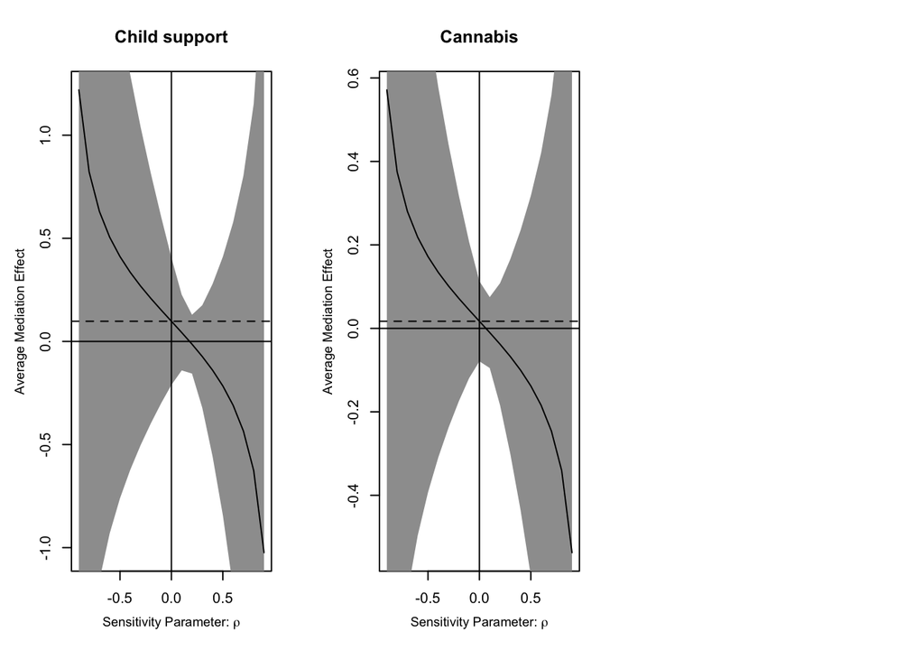

```r
# medsens region, one panel per wave.
par(mfrow = c(1, 3))
walk(names(analysis_data), function(nm) {
  d <- analysis_data[[nm]] %>%
    filter(!is.na(q_primary), !is.na(y_abs), group_f != "verbal") %>%
    mutate(treat = as.integer(group_f == "monetary"))
  if (nrow(d) < 20) return(invisible(NULL))

  f_m <- as.formula(paste("q_primary ~ treat +", paste(COVARS, collapse = " + ")))
  f_y <- as.formula(paste("y_abs ~ treat + q_primary +", paste(COVARS, collapse = " + ")))
  m_fit <- do.call(lm, list(formula = f_m, data = d))
  y_fit <- do.call(lm, list(formula = f_y, data = d))

  med <- tryCatch(mediation::mediate(m_fit, y_fit, treat = "treat",
                                     mediator = "q_primary", sims = 500),
                  error = function(e) NULL)
  if (is.null(med)) return(invisible(NULL))
  sens <- tryCatch(mediation::medsens(med, rho.by = 0.1), error = function(e) NULL)
  if (!is.null(sens)) plot(sens, main = WAVE_TOPICS[[str_remove(nm, "wave")]])
})
par(mfrow = c(1, 1))
```

# 12 Part 11: Sensitivity Analyses

```r
sens_w <- c(duration = "q_primary", unweighted = "exp_q_unw", log = "exp_q_log") %>%
  imap_dfr(function(v, nm) {
    across_waves(analysis_data, y = "y_abs",
                 rhs = c(v, "t_verbal", "t_money", COVARS)) %>%
      filter(term == v) %>% mutate(Weighting = nm)
  })

tab_sens_w <- sens_w %>%
  transmute(Topic = topic, Weighting, Estimate = round(estimate, 3),
            p = round(p.value, 3), Sig = stars(p.value), N = n) %>%
  arrange(Topic, Weighting)

cat("H2 under the three weightings:\n")
```

```
## H2 under the three weightings:
```

```r
print(as.data.frame(tab_sens_w))
```

```
##               Topic  Weighting Estimate     p Sig  N
## 1          Cannabis   duration    0.234 0.838     76
## 2          Cannabis        log    0.145 0.900     76
## 3          Cannabis unweighted    0.054 0.962     76
## 4     Child support   duration    1.095 0.153     81
## 5     Child support        log    1.129 0.154     81
## 6     Child support unweighted    1.105 0.167     81
## 7 Energy transition   duration    5.209 0.140     22
## 8 Energy transition        log    5.001 0.170     22
## 9 Energy transition unweighted    4.743 0.197     22
```

```r
write_latex_table(tab_sens_w, "tab_sens_weighting",
                  caption = "H2 under three quality weightings")
```

```r
sens_c <- c(primary = "q_primary", news_only = "exp_q_dur_news",
            incl_search = "exp_q_dur_all") %>%
  imap_dfr(function(v, nm) {
    across_waves(analysis_data, y = "y_abs",
                 rhs = c(v, "t_verbal", "t_money", COVARS)) %>%
      filter(term == v) %>% mutate(`Category set` = nm)
  })

tab_sens_c <- sens_c %>%
  transmute(Topic = topic, `Category set`, Estimate = round(estimate, 3),
            p = round(p.value, 3), Sig = stars(p.value), N = n) %>%
  arrange(Topic, `Category set`)

print(as.data.frame(tab_sens_c))
```

```
##               Topic Category set Estimate     p Sig   N
## 1          Cannabis  incl_search    0.610 0.597      97
## 2          Cannabis    news_only   -0.178 0.894      51
## 3          Cannabis      primary    0.234 0.838      76
## 4     Child support  incl_search    1.183 0.124     128
## 5     Child support    news_only    1.185 0.125      74
## 6     Child support      primary    1.095 0.153      81
## 7 Energy transition  incl_search    2.405 0.349      87
## 8 Energy transition    news_only   -3.342 0.675      13
## 9 Energy transition      primary    5.209 0.140      22
```

```r
write_latex_table(tab_sens_c, "tab_sens_category_set",
                  caption = "H2 under three category sets")
```

```r
# Reading rule fixed in advance: if the interaction survives, the moderator
# is not merely a proxy for cognitive engagement; if not, that cannot be
# ruled out, and the adjustment is partial given a reliability of .61.
# Same specification as H4a, plus nfc. Anything else would confound the
# adjustment with a change in the model.
sens_nfc <- map_dfr(DIET_VARIANTS, function(v) {
  g <- paste0("hab_", v, "_level_group")
  across_waves(analysis_data, y = "y_abs",
               rhs = c("t_verbal", "t_money", g,
                       paste0("t_verbal:", g), paste0("t_money:", g),
                       COVARS, "nfc")) %>%
    filter(str_detect(term, "^t_verbal|^t_money")) %>%
    mutate(Variant = v,
           Arm = if_else(str_detect(term, "verbal"), "Verbal", "Monetary"),
           Term = if_else(str_detect(term, ":"), "Interaction", "Low group"))
})

# Side by side with H4a, so the reader sees what the adjustment does rather
# than two tables that have to be compared by hand.
tab_sens_nfc <- h4a %>%
  transmute(topic, Variant, Arm, Term, est_h4a = estimate, p_h4a = p.value, n_h4a = n) %>%
  left_join(sens_nfc %>%
              transmute(topic, Variant, Arm, Term,
                        est_nfc = estimate, p_nfc = p.value, n_nfc = n),
            by = c("topic", "Variant", "Arm", "Term")) %>%
  filter(Term == "Interaction", Arm == "Monetary") %>%
  transmute(Topic = topic, Variant,
            `Without NFC` = round(est_h4a, 3), `p (without)` = round(p_h4a, 3),
            `N (without)` = n_h4a,
            `With NFC` = round(est_nfc, 3), `p (with)` = round(p_nfc, 3),
            `N (with)` = n_nfc) %>%
  arrange(Topic, Variant)

cat("H4a monetary interaction, with and without need for cognition:\n")
```

```
## H4a monetary interaction, with and without need for cognition:
```

```r
print(as.data.frame(tab_sens_nfc))
```

```
##               Topic        Variant Without NFC p (without) N (without) With NFC
## 1          Cannabis           news       0.379       0.103         468    0.394
## 2          Cannabis news_corrected       0.133       0.536         536   -0.042
## 3          Cannabis        overall      -0.316       0.131         554   -0.396
## 4     Child support           news      -0.485       0.031         465   -0.512
## 5     Child support news_corrected      -0.331       0.121         528   -0.366
## 6     Child support        overall      -0.007       0.971         547    0.007
## 7 Energy transition           news       0.176       0.442         467    0.245
## 8 Energy transition news_corrected      -0.169       0.429         531   -0.237
## 9 Energy transition        overall      -0.225       0.281         549   -0.158
##   p (with) N (with)
## 1    0.107      419
## 2    0.856      472
## 3    0.077      484
## 4    0.023      465
## 5    0.087      528
## 6    0.972      547
## 7    0.311      425
## 8    0.298      481
## 9    0.478      496
```

```r
write_latex_table(tab_sens_nfc, "tab_sens_nfc",
                  caption = "H4a interaction adjusted for need for cognition")

# The sample shrinks because NFC is missing for 107 participants, so part of
# any change is compositional rather than due to the adjustment. Refitting
# H4a on the NFC-complete sample separates the two.
sens_nfc_same_n <- map_dfr(DIET_VARIANTS, function(v) {
  g <- paste0("hab_", v, "_level_group")
  sub <- map(analysis_data, ~ filter(.x, !is.na(nfc)))
  across_waves(sub, y = "y_abs",
               rhs = c("t_verbal", "t_money", g,
                       paste0("t_verbal:", g), paste0("t_money:", g),
                       COVARS)) %>%
    filter(str_detect(term, "^t_money:")) %>%
    mutate(Variant = v)
})

cat("\nH4a on the NFC-complete sample, without the adjustment:\n")
```

```
##
## H4a on the NFC-complete sample, without the adjustment:
```

```r
sens_nfc_same_n %>%
  transmute(Topic = topic, Variant, Estimate = round(estimate, 3),
            p = round(p.value, 3), N = n) %>%
  arrange(Topic, Variant) %>%
  as.data.frame() %>% print()
```

```
##               Topic        Variant Estimate     p   N
## 1          Cannabis           news    0.408 0.097 419
## 2          Cannabis news_corrected    0.011 0.962 472
## 3          Cannabis        overall   -0.395 0.080 484
## 4     Child support           news   -0.485 0.031 465
## 5     Child support news_corrected   -0.331 0.121 528
## 6     Child support        overall   -0.007 0.971 547
## 7 Energy transition           news    0.247 0.307 425
## 8 Energy transition news_corrected   -0.226 0.319 481
## 9 Energy transition        overall   -0.160 0.472 496
```

# 13 Part 12: Knowledge Outcome

```r
cat("ITT on knowledge change:\n")
```

```
## ITT on knowledge change:
```

```r
kno_itt <- across_waves(analysis_data, y = "kno_signed",
                        rhs = c("t_verbal", "t_money"))

tab_kno_itt <- bind_rows(
  present(kno_itt, "^t_verbal") %>% mutate(Arm = "Verbal", .after = Topic),
  present(kno_itt, "^t_money")  %>% mutate(Arm = "Monetary", .after = Topic)
) %>% arrange(Topic, Arm)
print(as.data.frame(tab_kno_itt))
```

```
##               Topic      Arm Estimate    SE CI low CI high     p Sig   N
## 1          Cannabis Monetary    0.383 0.067  0.251   0.514 0.000 *** 606
## 2          Cannabis   Verbal    0.396 0.066  0.267   0.525 0.000 *** 606
## 3     Child support Monetary    0.756 0.087  0.585   0.926 0.000 *** 586
## 4     Child support   Verbal    0.627 0.091  0.447   0.806 0.000 *** 586
## 5 Energy transition Monetary    0.302 0.069  0.166   0.439 0.000 *** 598
## 6 Energy transition   Verbal    0.205 0.067  0.073   0.338 0.002  ** 598
##   adj. R2
## 1   0.068
## 2   0.068
## 3   0.123
## 4   0.123
## 5   0.029
## 6   0.029
```

```r
write_latex_table(tab_kno_itt, "tab_knowledge_itt", caption = "ITT on knowledge change")

# ANCOVA: post-test conditional on baseline, the prespecified robustness
# check. It is more efficient than the difference score when the pre-post
# correlation is below one, which it is here.
cat("\nANCOVA: post-test knowledge conditional on baseline:\n")
```

```
##
## ANCOVA: post-test knowledge conditional on baseline:
```

```r
kno_ancova <- across_waves(analysis_data, y = "kno_post",
                           rhs = c("t_verbal", "t_money", "kno_pre", COVARS))

tab_kno_ancova <- bind_rows(
  present(kno_ancova, "^t_verbal") %>% mutate(Arm = "Verbal", .after = Topic),
  present(kno_ancova, "^t_money")  %>% mutate(Arm = "Monetary", .after = Topic)
) %>% arrange(Topic, Arm)
print(as.data.frame(tab_kno_ancova))
```

```
##               Topic      Arm Estimate    SE CI low CI high     p Sig   N
## 1          Cannabis Monetary    0.341 0.058  0.227   0.454 0.000 *** 567
## 2          Cannabis   Verbal    0.365 0.057  0.254   0.477 0.000 *** 567
## 3     Child support Monetary    0.588 0.067  0.456   0.719 0.000 *** 558
## 4     Child support   Verbal    0.496 0.070  0.358   0.634 0.000 *** 558
## 5 Energy transition Monetary    0.286 0.058  0.173   0.400 0.000 *** 565
## 6 Energy transition   Verbal    0.168 0.057  0.057   0.279 0.003  ** 565
##   adj. R2
## 1   0.420
## 2   0.420
## 3   0.304
## 4   0.304
## 5   0.377
## 6   0.377
```

```r
write_latex_table(tab_kno_ancova, "tab_knowledge_ancova",
                  caption = "Knowledge: ANCOVA robustness check")
```

```r
cat("Encountered quality and knowledge change:\n")
```

```
## Encountered quality and knowledge change:
```

```r
kno_q <- across_waves(analysis_data, y = "kno_signed",
                      rhs = c("q_primary", "t_verbal", "t_money", COVARS))

tab_kno_q <- present(kno_q, "^q_primary$")
print(as.data.frame(tab_kno_q))
```

```
##               Topic Estimate    SE CI low CI high     p Sig  N adj. R2
## 1     Child support   -0.481 0.624 -1.726   0.765 0.444     81   0.116
## 2 Energy transition    0.098 2.174 -4.745   4.941 0.965     22   0.304
## 3          Cannabis    0.975 0.844 -0.711   2.661 0.252     76  -0.013
```

```r
write_latex_table(tab_kno_q, "tab_knowledge_quality",
                  caption = "Quality and knowledge change")
```

```r
cat("Uptake LATE on knowledge change:\n")
```

```
## Uptake LATE on knowledge change:
```

```r
kno_late <- across_waves(analysis_data, y = "kno_signed",
                         rhs = c("exp_topic_uptake_yn", COVARS),
                         instruments = c("t_verbal", "t_money", COVARS))

tab_kno_late <- kno_late %>%
  filter(term == "exp_topic_uptake_yn") %>%
  transmute(Topic = topic, Estimate = round(estimate, 3), SE = round(std.error, 3),
            p = round(p.value, 3), Sig = stars(p.value), N = n,
            `First-stage F` = round(first_stage_F, 2))
print(as.data.frame(tab_kno_late))
```

```
##               Topic Estimate    SE p Sig   N First-stage F
## 1     Child support    1.949 0.289 0 *** 558         39.03
## 2 Energy transition    1.118 0.288 0 *** 565         20.98
## 3          Cannabis    1.703 0.336 0 *** 567         22.03
```

```r
write_latex_table(tab_kno_late, "tab_knowledge_late",
                  caption = "Uptake LATE on knowledge change")
```

```r
# Knowledge analogue of H4b, for the same three diet definitions.
kno_mod <- map_dfr(DIET_VARIANTS, function(v) {
  g <- paste0("hab_", v, "_level_group")
  across_waves(analysis_data, y = "kno_signed",
               rhs = c(paste0("exp_topic_uptake_yn * ", g), COVARS),
               instruments = c(paste0("t_verbal * ", g),
                               paste0("t_money * ", g), COVARS)) %>%
    filter(str_detect(term, "^exp_topic_uptake_yn")) %>%
    mutate(Variant = v,
           Term = if_else(str_detect(term, ":"), "Interaction", "Low group"))
})

tab_kno_mod <- present(kno_mod, ".", fit = FALSE) %>%
  mutate(Variant = kno_mod$Variant, Term = kno_mod$Term, .after = Topic) %>%
  mutate(`First-stage F` = round(kno_mod$first_stage_F, 2)) %>%
  arrange(Topic, Variant, desc(Term))

cat("Knowledge LATE by habitual-quality group:\n")
```

```
## Knowledge LATE by habitual-quality group:
```

```r
print(as.data.frame(tab_kno_mod))
```

```
##                Topic        Variant        Term Estimate    SE CI low CI high
## 1           Cannabis           news   Low group    1.654 0.407  0.855   2.452
## 2           Cannabis           news Interaction   -0.292 0.752 -1.766   1.182
## 3           Cannabis news_corrected   Low group    1.812 0.553  0.729   2.895
## 4           Cannabis news_corrected Interaction   -0.391 0.693 -1.749   0.967
## 5           Cannabis        overall   Low group    1.325 0.406  0.529   2.121
## 6           Cannabis        overall Interaction    0.773 0.716 -0.630   2.176
## 7      Child support           news   Low group    2.016 0.429  1.176   2.857
## 8      Child support           news Interaction   -0.383 0.577 -1.515   0.749
## 9      Child support news_corrected   Low group    2.713 0.555  1.625   3.801
## 10     Child support news_corrected Interaction   -1.267 0.662 -2.565   0.030
## 11     Child support        overall   Low group    1.823 0.422  0.996   2.651
## 12     Child support        overall Interaction   -0.018 0.552 -1.101   1.064
## 13 Energy transition           news   Low group    1.170 0.440  0.307   2.033
## 14 Energy transition           news Interaction   -0.091 0.592 -1.251   1.069
```

[output cut: 23 more lines]

```r
write_latex_table(tab_kno_mod, "tab_knowledge_moderation",
                  caption = "Knowledge LATE by habitual quality")
```

# 14 Part 13: Detection Limits

Minimum detectable effect at 80 per cent power and a two-sided level of .05, and Type S and Type M error at assumed true effects (Gelman & Carlin, 2014). Nothing is re-estimated; the standard errors come from the models above.

```r
mde <- function(se, power = .80, alpha = .05) {
  (qnorm(1 - alpha / 2) + qnorm(power)) * se
}

design_analysis <- function(true_effect, se, alpha = .05, n_sim = 2e5) {
  z     <- qnorm(1 - alpha / 2)
  power <- (1 - pnorm(z - true_effect / se)) + pnorm(-z - true_effect / se)
  draws <- rnorm(n_sim, true_effect, se)
  sig   <- abs(draws) > z * se
  c(power        = power,
    type_s       = pnorm(-z - true_effect / se) / power,
    exaggeration = mean(abs(draws[sig])) / abs(true_effect))
}

focal <- bind_rows(
  itt_abs    %>% filter(term == "t_money")   %>% mutate(Model = "ITT, absolute change"),
  realized   %>% filter(term == "t_money")   %>% mutate(Model = "H1a, realization"),
  qlevel_adj %>% filter(term == "t_money")   %>% mutate(Model = "Level of encountered OIEQ"),
  h2_adj     %>% filter(term == "q_primary") %>% mutate(Model = "H2, quality on attitude"),
  late       %>% filter(term == "exp_topic_uptake_yn") %>% mutate(Model = "LATE, uptake"),
  h4a        %>% filter(Term == "Interaction", Arm == "Monetary") %>%
              mutate(Model = paste0("H4a interaction (", DIET_SHORT[Variant], ")"))
) %>%
  transmute(Model, Topic = topic,
            Estimate   = round(estimate, 3),
            SE         = round(std.error, 3),
            MDE        = round(mde(std.error), 3),
            `Est./MDE` = round(abs(estimate) / mde(std.error), 2),
            N = n)

cat("Minimum detectable effect at 80% power, alpha = .05:\n")
```

```
## Minimum detectable effect at 80% power, alpha = .05:
```

```r
print(as.data.frame(focal))
```

```
##                        Model             Topic Estimate    SE   MDE Est./MDE
## 1       ITT, absolute change     Child support    0.278 0.103 0.289     0.96
## 2       ITT, absolute change Energy transition    0.021 0.101 0.283     0.07
## 3       ITT, absolute change          Cannabis    0.248 0.098 0.275     0.90
## 4           H1a, realization     Child support    0.285 0.034 0.094     3.03
## 5           H1a, realization Energy transition    0.058 0.020 0.056     1.04
## 6           H1a, realization          Cannabis    0.205 0.034 0.095     2.17
## 7  Level of encountered OIEQ     Child support    0.048 0.126 0.352     0.14
## 8  Level of encountered OIEQ Energy transition   -0.004 0.075 0.210     0.02
## 9  Level of encountered OIEQ          Cannabis    0.044 0.051 0.142     0.31
## 10   H2, quality on attitude     Child support    1.095 0.759 2.126     0.52
## 11   H2, quality on attitude Energy transition    5.209 3.248 9.100     0.57
## 12   H2, quality on attitude          Cannabis    0.234 1.142 3.198     0.07
## 13              LATE, uptake     Child support    0.636 0.295 0.827     0.77
## 14              LATE, uptake Energy transition    0.042 0.393 1.102     0.04
```

[output cut: 35 more lines]

```r
write_latex_table(focal, "tab_detection_limits",
                  caption = "Minimum detectable effects")


# The quality MDE expressed in within-wave SDs of the quality measure.
cat("\nMDE for the level of encountered OIEQ, in within-wave SDs:\n")
```

```
##
## MDE for the level of encountered OIEQ, in within-wave SDs:
```

```r
map_dfr(analysis_data, ~ tibble(sd_q = sd(.x$q_primary, na.rm = TRUE)), .id = "wave") %>%
  mutate(wave = as.integer(str_remove(wave, "wave"))) %>%
  left_join(qlevel_adj %>% filter(term == "t_money") %>% select(wave, std.error),
            by = "wave") %>%
  transmute(Topic       = WAVE_TOPICS[as.character(wave)],
            SD          = round(sd_q, 3),
            MDE         = round(mde(std.error), 3),
            `MDE in SD` = round(mde(std.error) / sd_q, 2)) %>%
  as.data.frame() %>% print()
```

```
##               Topic    SD   MDE MDE in SD
## 1     Child support 0.137 0.352      2.56
## 2 Energy transition 0.108 0.210      1.93
## 3          Cannabis 0.109 0.142      1.31
```

```r
# Design analysis at assumed true effects. SEs are taken from the fitted
# models rather than entered manually.
set.seed(20260913)
se_h4a  <- h4a %>% filter(Term == "Interaction", Arm == "Monetary",
                          Variant == "news", wave == 1) %>% pull(std.error)
se_late <- late %>% filter(term == "exp_topic_uptake_yn", wave == 1) %>% pull(std.error)

tab_design <- tibble(Model = c(rep("H4a interaction, news", 3), rep("LATE, child support", 3)),
                     SE    = c(rep(se_h4a, 3), rep(se_late, 3)),
                     `True effect` = rep(c(0.20, 0.30, 0.40), 2)) %>%
  mutate(res = map2(`True effect`, SE, design_analysis),
         Power          = round(map_dbl(res, "power"), 2),
         `Type S`       = round(100 * map_dbl(res, "type_s"), 1),
         Exaggeration   = round(map_dbl(res, "exaggeration"), 1)) %>%
  select(Model, `True effect`, SE, Power, `Type S`, Exaggeration) %>%
  mutate(SE = round(SE, 3))

cat("\nDesign analysis at plausible true effect sizes:\n")
```

```
##
## Design analysis at plausible true effect sizes:
```

```r
print(as.data.frame(tab_design))
```

```
##                   Model True effect    SE Power Type S Exaggeration
## 1 H4a interaction, news         0.2 0.225  0.14    1.5          2.8
## 2 H4a interaction, news         0.3 0.225  0.27    0.2          1.9
## 3 H4a interaction, news         0.4 0.225  0.43    0.0          1.5
## 4   LATE, child support         0.2 0.295  0.10    4.0          3.6
## 5   LATE, child support         0.3 0.295  0.17    0.8          2.5
## 6   LATE, child support         0.4 0.295  0.27    0.2          1.9
```

```r
write_latex_table(tab_design, "tab_design_analysis", digits = 2,
                  caption = "Type S and Type M errors at plausible effect sizes")
```

# 15 Part 14: Hypothesis Summary

Index of hypotheses and their principal table, plus a listing of the LaTeX fragments written by this script.

```r
summary_tab <- tribble(
  ~Hypothesis, ~Question, ~Key_table,
  "H1a", "Encouragement raises the probability of realizing a characterizable environment", "tab_h1a_realization",
  "H1b", "More effort, higher encountered quality",            "tab_h1b_effort_quality",
  "H2",  "Higher quality, more attitude change",               "tab_h2_quality_attitude",
  "H3a", "Quality-attitude link stronger at low habitual quality", "tab_h3a_quality_moderation",
  "H3b", "Indirect effect stronger at low habitual quality",   "tab_h3b_indirect_effects",
  "H4a", "Treatment effect stronger at low habitual quality",  "tab_h4a_treatment_moderation",
  "H4b", "Uptake LATE stronger at low habitual quality",       "tab_h4b_late_interaction"
)

print(as.data.frame(summary_tab))
```

```
##   Hypothesis
## 1        H1a
## 2        H1b
## 3         H2
## 4        H3a
## 5        H3b
## 6        H4a
## 7        H4b
##                                                                          Question
## 1 Encouragement raises the probability of realizing a characterizable environment
## 2                                         More effort, higher encountered quality
## 3                                            Higher quality, more attitude change
## 4                          Quality-attitude link stronger at low habitual quality
## 5                                Indirect effect stronger at low habitual quality
## 6                               Treatment effect stronger at low habitual quality
## 7                                    Uptake LATE stronger at low habitual quality
##                      Key_table
## 1          tab_h1a_realization
## 2       tab_h1b_effort_quality
## 3      tab_h2_quality_attitude
## 4   tab_h3a_quality_moderation
## 5     tab_h3b_indirect_effects
## 6 tab_h4a_treatment_moderation
## 7     tab_h4b_late_interaction
```

```r
write_csv(summary_tab, file.path(table_dir, "hypothesis_index.csv"))


print(list.files(table_dir, pattern = "\\.tex$"))
```

```
##  [1] "tab_balance.tex"                  "tab_composition_arm_by_diet.tex"
##  [3] "tab_composition_arms.tex"         "tab_composition_diet.tex"
##  [5] "tab_covariate_missingness.tex"    "tab_coverage.tex"
##  [7] "tab_descriptives_by_wave.tex"     "tab_descriptives.tex"
##  [9] "tab_design_analysis.tex"          "tab_detection_limits.tex"
## [11] "tab_first_stage_effort.tex"       "tab_first_stage.tex"
## [13] "tab_h1a_realization.tex"          "tab_h1b_effort_quality.tex"
## [15] "tab_h2_lee_bounds.tex"            "tab_h2_quality_attitude.tex"
## [17] "tab_h3a_quality_moderation.tex"   "tab_h3a_subgroups.tex"
## [19] "tab_h3b_indirect_effects.tex"     "tab_h3b_sensitivity.tex"
## [21] "tab_h4a_common_sample.tex"        "tab_h4a_continuous.tex"
## [23] "tab_h4a_treatment_moderation.tex" "tab_h4b_continuous.tex"
## [25] "tab_h4b_late_full.tex"            "tab_h4b_late_interaction.tex"
## [27] "tab_h4b_subgroups.tex"            "tab_itt_absolute.tex"
## [29] "tab_itt_signed.tex"               "tab_knowledge_ancova.tex"
## [31] "tab_knowledge_itt.tex"            "tab_knowledge_late.tex"
## [33] "tab_knowledge_moderation.tex"     "tab_knowledge_quality.tex"
## [35] "tab_missingness_by_arm.tex"       "tab_q_level_lee_bounds.tex"
## [37] "tab_q_level_scored_by_arm.tex"    "tab_q_level.tex"
## [39] "tab_sens_category_set.tex"        "tab_sens_nfc.tex"
## [41] "tab_sens_weighting.tex"           "tab_triage.tex"
```